# DOG MICROBIOME BASIC ANALYSES

## Background

There are three dogs which are treated with increased percentage of a compound in their diet: 5 different treatments (0-4, representing an increased percentage of a compound in their diet) Analyses included here:

- Import .biom and .tre files generated in QIIME as well as metadata file: merge these objects in a phyloseq object
- Basic data filter: assess number of reads/sample, plot rarefaction curves, and exclude low abundance OTUs and samples that do not meet minimum number of reads cutoff.
- Basic exploratory plots including bar plots, alpha- and beta-diversity, heatmaps.
- Differential abundance testing by a) Dog and b) Treatment

## This tutorial should be run in an interactive session. Please do not runnning anything on the headnode.

### To get to a compute node do

```bash
qsub -I -q UCTlong -l walltime=08:00:00
```

Once you are on a compute node you will see that the prompt changes from `@srvslshpc001` to `@srvslshpc60X` e.g.

```bash
gerrit@srvslshpc001:~> qsub -I -q UCTlong -l walltime=08:00:00
qsub: waiting for job 1598565.srvslshpc001 to start
qsub: job 1598565.srvslshpc001 ready

gerrit@srvslshpc601:~> hostname
srvslshpc601
```

## Make an output directory for R downstream analyses

**NB - replace hpc30 with your user account**

```bash
mkdir /researchdata/fhgfs/hpc30/R_downstream
```

## Load the R environment required

```bash
module load software/R-3.3.0
```

## Startup R

enter 'R' into terminal

## Import data and create phyloseq object

**Import BIOM file (generated in QIIME) into a phyloseq object**

**Import custom functions used in script**

```
## NMF - BioConductor layer [OK] | Shared memory capabilities [NO: bigmemory] | Cores 63/64
```

```
##   To enable shared memory capabilities, try: install.extras('
## NMF
## ')
```

[output not shown]

**Set the working directory and import data** **NB replace the directory listed below to /researchdata/fhgfs/hpc30, substituting 'hpc30' with the name that has been given to you in the class**

```
## [1] 179
```

**Data cleanup**

```
## [1] "Rank1" "Rank2" "Rank3" "Rank4" "Rank5" "Rank6" "Rank7"
```

**Import metadata and merge with phyloseq object**

```
##       Dog Treatment
## Dog1    B         2
## Dog2    G         3
## Dog3    K         3
## Dog8    B         4
## Dog9    G         0
## Dog10   K         4
```

```
##  [1] "Dog1"  "Dog2"  "Dog3"  "Dog8"  "Dog9"  "Dog10" "Dog15" "Dog16"
##  [9] "Dog17" "Dog22" "Dog23" "Dog24" "Dog29" "Dog30" "Dog31"
```

```
## [1] "Dog10" "Dog15" "Dog16" "Dog17" "Dog1"  "Dog22"
```

```
## [1] 15
```

```
## [1] 15
```

```
## [1] 15
```

```
## [1] 15
```

```
## 'data.frame':    15 obs. of  2 variables:
## Formal class 'sample_data' [package "phyloseq"] with 4 slots
##   ..@ .Data    :List of 2
##   .. ..$ : Factor w/ 3 levels "B","G","K": 3 1 2 3 1 1 2 3 1 2 ...
##   .. ..$ : int  4 1 4 0 2 3 1 2 0 3 ...
##   ..@ names    : chr  "Dog" "Treatment"
##   ..@ row.names: chr  "Dog10" "Dog15" "Dog16" "Dog17" ...
##   ..@ .S3Class : chr "data.frame"
```

**Save phyloseq object as an .RData file**

## Explore number of reads per sample, make rarefaction curves and filter data as necessary

**Explore number of reads per sample**

```
## [1] 0
```

```
## [1] 63980
```

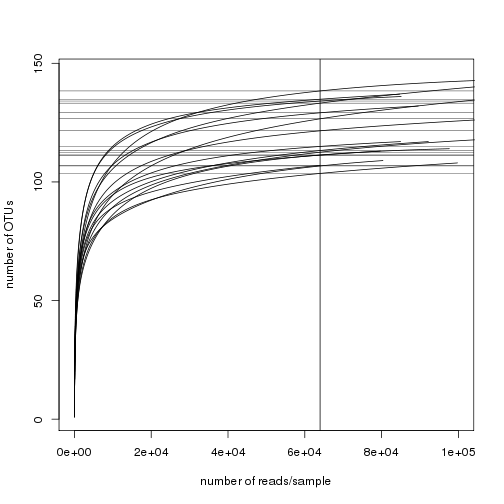

[output not shown]

[output cut: 6921 more lines]

[output not shown]

All samples have sufficient sequencing depth for inclusion in downstream analyses. The vertical line in the above plot indicates the sample with the lowest number of reads. Now we will scale data to account for differences in the number of reads/sample and filter rare OTUs that are not of biological interest for the purpose of this analysis (e.g. occurs only in one sample).

**Standardize abundances to median sequence depth**

**Apply mild OTU filter**

Select OTUs where the rowsum for that OTU has at least 20% of samples with a count of 10 each OR where that OTU > 0.001% of the total median count (for cases where the minority of samples may have high counts of a rare OTU)

```
## [1] 135
```

## **Basic exploratory plots: alpha- and beta-diversity, barplots, heatmap**

**Alpha diversity by dog**

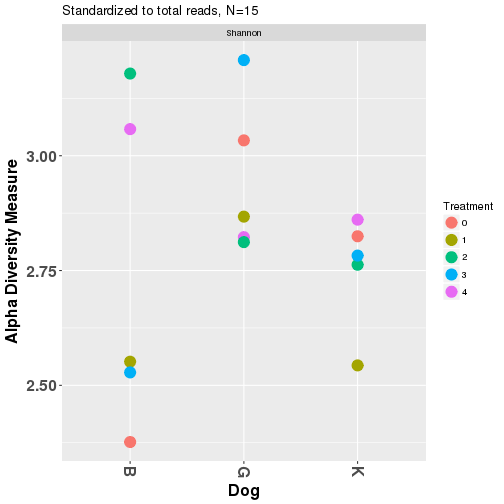

Is there a significant difference in alpha diversity between dogs irrespective of treatment?

```
##        Shannon Dog
## Dog10 2.859687   K
## Dog15 2.550581   B
## Dog16 2.819618   G
## Dog17 2.823232   K
## Dog1  3.177816   B
## Dog22 2.525255   B
```

```
##
##  Kruskal-Wallis rank sum test
##
## data:  temp[, 1] by temp[, 2]
## Kruskal-Wallis chi-squared = 2.54, df = 2, p-value = 0.2808
```

```
##   Kruskal-Wallis rank sum test
##
## data: x and group
## Kruskal-Wallis chi-squared = 2.54, df = 2, p-value = 0.28
##
##
##                            Comparison of x by group
##                                 (No adjustment)
## Col Mean-|
## Row Mean |          B          G
## ---------+----------------------
##        G |  -1.343502
##          |     0.0896
##        K |   0.070710   1.414213
##          |     0.4718     0.0786
```

Dog G has higher alpha diversity than dogs K and B irrespective of treatment, but this difference is not significant

**Alpha diversity by treatment**

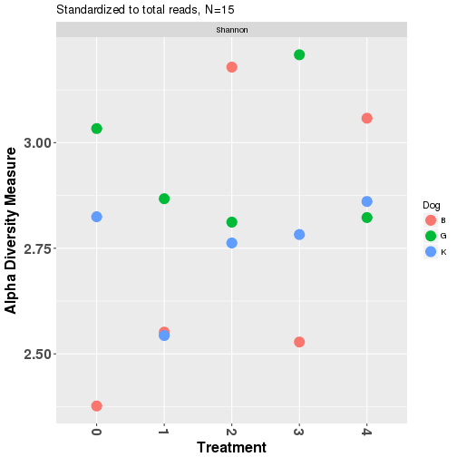

Are there significant differences in alpha diversity by treatment?

```
##        Shannon Treatment
## Dog10 2.859687         4
## Dog15 2.550581         1
## Dog16 2.819618         4
## Dog17 2.823232         0
## Dog1  3.177816         2
## Dog22 2.525255         3
```

```
##
##  Kruskal-Wallis rank sum test
##
## data:  temp[, 1] by temp[, 2]
## Kruskal-Wallis chi-squared = 1.5667, df = 4, p-value = 0.8148
```

```
##   Kruskal-Wallis rank sum test
##
## data: x and group
## Kruskal-Wallis chi-squared = 1.5667, df = 4, p-value = 0.81
##
##
##                            Comparison of x by group
##                                 (No adjustment)
## Col Mean-|
## Row Mean |          0          1          2          3
## ---------+--------------------------------------------
##        1 |   0.365148
##          |     0.3575
##        2 |  -0.365148  -0.730296
##          |     0.3575     0.2326
##        3 |  -0.091287  -0.456435   0.273861
##          |     0.4636     0.3240     0.3921
##        4 |  -0.821583  -1.186732  -0.456435  -0.730296
##          |     0.2057     0.1177     0.3240     0.2326
```

**Beta diversity using NMDS with Bray-Curtis as distance metric**

```
## Square root transformation
## Wisconsin double standardization
## *** Solution reached
```

```
##
## Call:
## metaMDS(comm = veganifyOTU(physeq), distance = distance, k = 2,      trymax = 100)
##
## global Multidimensional Scaling using monoMDS
##
## Data:     wisconsin(sqrt(veganifyOTU(physeq)))
## Distance: bray
##
## Dimensions: 2
## Stress:     0.07152504
## Stress type 1, weak ties
## Two convergent solutions found after 20 tries
## Scaling: centring, PC rotation, halfchange scaling
## Species: expanded scores based on 'wisconsin(sqrt(veganifyOTU(physeq)))'
```

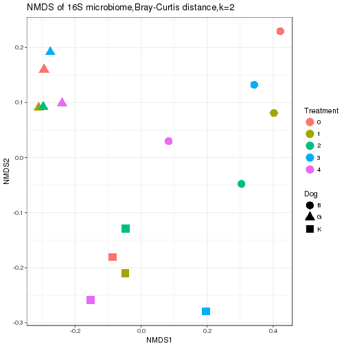

**Beta diversity using NMDS with Unifrac as distance metric**

```
## *** Solution reached
```

```
##
## Call:
## metaMDS(comm = ps.dist)
##
## global Multidimensional Scaling using monoMDS
##
## Data:     ps.dist
## Distance: user supplied
##
## Dimensions: 2
## Stress:     0.09882136
## Stress type 1, weak ties
## Two convergent solutions found after 20 tries
## Scaling: centring, PC rotation
## Species: scores missing
```

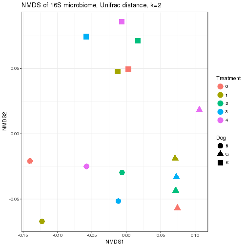

**Create a heatmap of taxa merged at the lowest available taxonomic level**

```
## [1] "Removing phylogenetic tree"
```

```
## [1] "There are now 58 merged taxa"
```

```
## [1] 58
```

```
## [1] "including all samples"
## [1] "including all otus"
```

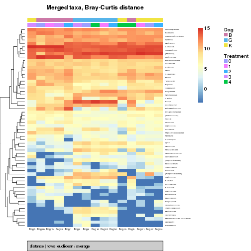

```
## $Rowv
## 'dendrogram' with 2 branches and 58 members total, at height 31.65134
##
## $rowInd
##  [1] 54 22 19 28 44 30 33 35 17 37 39 56 51 57 20  4 50 42 25  8 40  5 21
## [24] 15  3 49 13 10 18 43 27 26 14  7  6  9 52 55 16 34 41 47 38 12 48 11
## [47] 53 45  2 36 24 31 58 23 29 32 46  1
##
## $colInd
##  [1] 13  9  2  6  5 10 15  3  7 11  1 14 12  4  8
```

## **Barplots by dog**

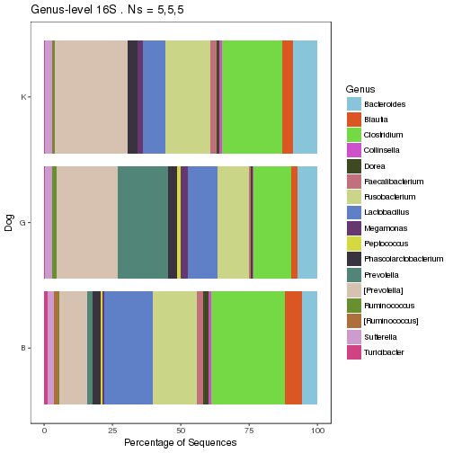

## Detect taxa/OTUs that differ significantly by Dog

convert phyloseq object to metagenomeSeq obj. NB use raw data not standardized:

```
## [1] 135
```

```
## Default value being used.
```

```
## MRexperiment (storageMode: environment)
## assayData: 135 features, 15 samples
##   element names: counts
## protocolData: none
## phenoData
##   sampleNames: Dog10 Dog15 ... Dog9 (15 total)
##   varLabels: Dog Treatment
##   varMetadata: labelDescription
## featureData
##   featureNames: OTU_30 OTU_41 ... OTU_66 (135 total)
##   fvarLabels: OTUname
##   fvarMetadata: labelDescription
## experimentData: use 'experimentData(object)'
## Annotation:
```

**Use Random forests analysis to detect taxa that are good predictors of Dog**

Example used: Dog G vs. Dog B (all treatment points)

```
## [1] 10
```

```
## [1] "0 samples did not have response variable data, removing these..."
## [1] "Data set size:  10 samples with 5 and 5 samples per class"
## [1] "Cross-validated error rates associated with stepwise reduction of features:"
## 135  68  34  17   8   4   2   1
## 0.0 0.0 0.0 0.0 0.0 0.0 0.2 0.0
```

```
## [1] "*****************************"
## [1] "THE TOP 20 MOST IMPORTANT FEATURES WERE:"
##         predictors         B         G MeanDecreaseAccuracy
## OTU_121    OTU_121  9.671867  9.681629             9.993612
## OTU_51      OTU_51  8.804326  8.794635             9.104466
## OTU_8        OTU_8 10.147888 10.256865            10.526653
## OTU_72      OTU_72  9.560636  9.639463            10.031998
## OTU_104    OTU_104  9.232706  9.125792             9.443961
## OTU_58      OTU_58  9.391857  9.411628             9.868075
## OTU_11      OTU_11  8.359543  8.290286             8.680334
## OTU_119    OTU_119  9.141466  9.134742             9.416359
## OTU_115    OTU_115  8.950253  8.937649             9.235798
## OTU_53      OTU_53  8.925435  8.801074             9.192012
## OTU_74      OTU_74  9.342631  9.406728             9.785011
## OTU_59      OTU_59  8.384654  8.370093             8.661476
## OTU_73      OTU_73  8.405341  8.385556             8.701166
## OTU_140    OTU_140  8.380246  8.371369             8.789388
## OTU_96      OTU_96  7.817527  7.903793             8.080081
## OTU_78      OTU_78  7.751269  7.708754             8.008854
## OTU_150    OTU_150  8.586375  8.567680             8.865167
## OTU_24      OTU_24  7.428018  7.468994             7.720773
## OTU_10      OTU_10  9.535855  9.464636             9.827861
## OTU_29      OTU_29  8.973883  8.878966             9.301188
##         MeanDecreaseGini                 tax
## OTU_121       0.08080000             P.copri
## OTU_51        0.08008667       Clostridiales
## OTU_8         0.07962000           P.copri.1
## OTU_72        0.07860000       Adlercreutzia
## OTU_104       0.07852000         Odoribacter
## OTU_58        0.07734000  Anaerobiospirillum
## OTU_11        0.07688000  Enterobacteriaceae
## OTU_119       0.07652000          Sutterella
## OTU_115       0.07576000        Enterococcus
## OTU_53        0.07570667      Clostridiaceae
## OTU_74        0.07478000  [Mogibacteriaceae]
## OTU_59        0.07470000      [Ruminococcus]
## OTU_73        0.07414000 Erysipelotrichaceae
## OTU_140       0.07386000       Fusobacterium
## OTU_96        0.07374000        Oscillospira
## OTU_78        0.07370000         Bacteroides
## OTU_150       0.07352667     Lachnospiraceae
## OTU_24        0.07346000   Lachnospiraceae.1
## OTU_10        0.07342000          B.producta
## OTU_29        0.07286000        Turicibacter
## [1] "*****************************"
```

```
## [1] "Training AUC=1"
## [1] "Training PPV=1"
## [1] "Training NPV=1"
```

```
## [1] "*****************************"
## [1] "Training set classification summary if using the top 3 features only"
## [1] "Feature(s) selected: OTU_121" "Feature(s) selected: OTU_51"
## [3] "Feature(s) selected: OTU_8"
##                 B         G MeanDecreaseAccuracy MeanDecreaseGini
## OTU_8   0.1447083 0.1438417            0.1290467          1.52652
## OTU_121 0.1430083 0.1389750            0.1261224          1.50398
## OTU_51  0.1139500 0.1111500            0.1011867          1.47938
##
## Call:
##  randomForest(formula = response ~ ., data = rf.data[, c(goodPredictors,      "response")], importance = T, proximity = T, ntree = ntree,      na.action = na.omit)
##                Type of random forest: classification
##                      Number of trees: 10000
## No. of variables tried at each split: 1
##
##         OOB estimate of  error rate: 0%
## Confusion matrix:
##   B G class.error
## B 5 0           0
## G 0 5           0
```

The class error rates are 0% (even one OTU enough to discriminate between Dog G and B?)

What if we used merged OTUs?

```
## [1] "Removing phylogenetic tree"
```

```
## [1] "There are now 58 merged taxa"
```

```
## [1] "0 samples did not have response variable data, removing these..."
## [1] "Data set size:  10 samples with 5 and 5 samples per class"
## [1] "Cross-validated error rates associated with stepwise reduction of features:"
##  58  29  14   7   4   1
## 0.0 0.0 0.0 0.0 0.0 0.1
```

```
## [1] "*****************************"
## [1] "THE TOP 20 MOST IMPORTANT FEATURES WERE:"
##         predictors        B        G MeanDecreaseAccuracy MeanDecreaseGini
## OTU_59      OTU_59 12.84573 12.75514             13.22767        0.1701578
## OTU_27      OTU_27 14.14560 14.15688             14.66689        0.1664900
## OTU_104    OTU_104 13.79309 13.76287             14.34825        0.1652714
## OTU_68      OTU_68 12.54870 12.48715             13.03041        0.1639057
## OTU_72      OTU_72 13.67522 13.74857             14.21517        0.1631848
## OTU_76      OTU_76 13.48093 13.57423             14.07012        0.1623467
## OTU_29      OTU_29 13.77678 13.69971             14.25054        0.1618883
## OTU_115    OTU_115 13.78611 13.66527             14.26590        0.1615750
## OTU_98      OTU_98 13.23068 13.23404             13.60197        0.1611457
## OTU_57      OTU_57 12.79080 12.78306             13.28220        0.1607600
## OTU_26      OTU_26 12.70062 12.54606             13.09699        0.1593200
## OTU_8        OTU_8 13.81179 13.67807             14.29226        0.1565095
## OTU_11      OTU_11 12.19598 12.23061             12.70349        0.1563300
## OTU_55      OTU_55 13.95863 13.71404             14.38892        0.1548617
## OTU_12      OTU_12 11.50679 11.36390             11.94686        0.1536400
## OTU_35      OTU_35 12.44178 12.45397             13.04827        0.1484333
## OTU_74      OTU_74 13.36003 13.41300             13.80032        0.1483867
## OTU_19      OTU_19 13.36975 13.20095             13.78641        0.1470000
## OTU_10      OTU_10 12.36814 12.38032             12.83683        0.1421733
## OTU_61      OTU_61 12.03922 12.09042             12.51234        0.1395000
##                           tax
## OTU_59         [Ruminococcus]
## OTU_27           Ruminococcus
## OTU_104           Odoribacter
## OTU_68     Anaerobiospirillum
## OTU_72          Adlercreutzia
## OTU_76           Oscillospira
## OTU_29           Turicibacter
## OTU_115          Enterococcus
## OTU_98                  Dorea
## OTU_57    Succinivibrionaceae
## OTU_26                  S24-7
## OTU_8                 P.copri
## OTU_11     Enterobacteriaceae
## OTU_55          Bacteroidales
## OTU_12          F.prausnitzii
## OTU_35            Allobaculum
## OTU_74     [Mogibacteriaceae]
## OTU_19               R.gnavus
## OTU_10             B.producta
## OTU_61  Peptostreptococcaceae
## [1] "*****************************"
```

```
## [1] "Training AUC=1"
## [1] "Training PPV=1"
## [1] "Training NPV=1"
```

```
## [1] "*****************************"
## [1] "Training set classification summary if using the top 3 features only"
## [1] "Feature(s) selected: OTU_59"  "Feature(s) selected: OTU_27"
## [3] "Feature(s) selected: OTU_104"
##                 B         G MeanDecreaseAccuracy MeanDecreaseGini
## OTU_104 0.1392500 0.1415667            0.1262033          1.52932
## OTU_27  0.1363083 0.1369833            0.1223476          1.49262
## OTU_59  0.1169167 0.1174750            0.1051862          1.48760
##
## Call:
##  randomForest(formula = response ~ ., data = rf.data[, c(goodPredictors,      "response")], importance = T, proximity = T, ntree = ntree,      na.action = na.omit)
##                Type of random forest: classification
##                      Number of trees: 10000
## No. of variables tried at each split: 1
##
##         OOB estimate of  error rate: 0%
## Confusion matrix:
##   B G class.error
## B 5 0           0
## G 0 5           0
```

**Differential abundance testing using MetagenomeSeq package**

Lets again compare dog G vs. dog B (merged taxa), this time using differential abundance testing

```
## [1] "0 of 10 samples were removed due to missing data"
```

```
## Default value being used.
```

```
## [1] "Dog will be modeled as a binary categorical predictor variable"
```

```
## Default value being used.
```

```
## it= 0, nll=18.47, log10(eps+1)=Inf, stillActive=58
## it= 1, nll=19.48, log10(eps+1)=0.01, stillActive=4
## it= 2, nll=19.52, log10(eps+1)=0.03, stillActive=1
## it= 3, nll=19.55, log10(eps+1)=0.01, stillActive=1
## it= 4, nll=19.63, log10(eps+1)=0.00, stillActive=0
## There were  25 OTUs significantly different between B vs. G that met
##  threshold criteria of p 0.05 absolute FC 1.25 and percentage presence in at least one group of 20 %
## [1] "writing results and model to file"
```

```
## [1] "/scratch/DB/bio/training/16SrRNA/16SrRNA-hex-tutorial/results/R_downstream/1_25FC_0.2_Dog_GvsB_taxa_merged_tax_annot.pdf"
```

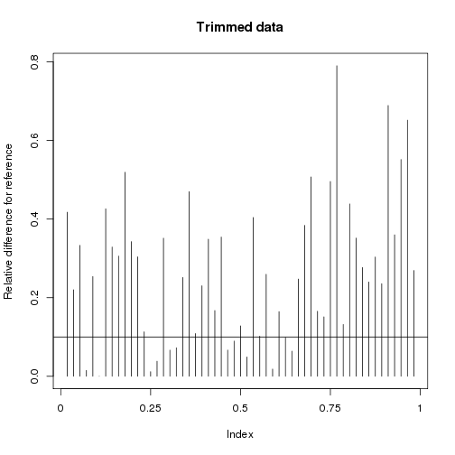

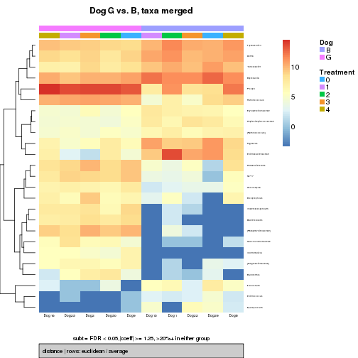

```
## [1] "making heatmap of results"
```

```
##         percent_positive_group0 percent_positive_group1
## OTU_11                      100                     100
## OTU_111                      80                      20
## OTU_19                      100                     100
## OTU_77                      100                      80
## OTU_29                      100                     100
## OTU_115                     100                      40
## OTU_61                      100                     100
## OTU_98                      100                     100
## OTU_10                      100                     100
## OTU_59                      100                     100
## OTU_12                      100                     100
## OTU_73                      100                     100
## OTU_44                       80                     100
## OTU_76                      100                     100
## OTU_27                      100                     100
## OTU_74                       60                     100
## OTU_69                       60                     100
## OTU_39                      100                     100
## OTU_8                       100                     100
## OTU_26                      100                     100
## OTU_57                       60                     100
## OTU_72                        0                     100
## OTU_68                       40                     100
## OTU_55                       20                     100
## OTU_36                       40                     100
##         +samples in group 0 +samples in group 1 mean_positive_group0
## OTU_11                    5                   5                 3645
## OTU_111                   4                   1                   32
## OTU_19                    5                   5                 1142
## OTU_77                    5                   4                   66
## OTU_29                    5                   5                 1147
## OTU_115                   5                   2                   10
## OTU_61                    5                   5                  160
## OTU_98                    5                   5                 1570
## OTU_10                    5                   5                 4032
## OTU_59                    5                   5                  105
## OTU_12                    5                   5                 1821
## OTU_73                    5                   5                  119
## OTU_44                    4                   5                   37
```

[output cut: 101 more lines]

```
## OTU_12        Ruminococcaceae   Faecalibacterium prausnitzii
## OTU_73    Erysipelotrichaceae               <NA>        <NA>
## OTU_44         Bacteroidaceae        Bacteroides coprophilus
## OTU_76        Ruminococcaceae       Oscillospira        <NA>
## OTU_27        Ruminococcaceae       Ruminococcus        <NA>
## OTU_74     [Mogibacteriaceae]               <NA>        <NA>
## OTU_69         Bacteroidaceae        Bacteroides   uniformis
## OTU_39     Porphyromonadaceae    Parabacteroides        <NA>
## OTU_8          Prevotellaceae         Prevotella       copri
## OTU_26                  S24-7               <NA>        <NA>
## OTU_57    Succinivibrionaceae               <NA>        <NA>
## OTU_72      Coriobacteriaceae      Adlercreutzia        <NA>
## OTU_68    Succinivibrionaceae Anaerobiospirillum        <NA>
## OTU_55                   <NA>               <NA>        <NA>
## OTU_36   [Paraprevotellaceae]               <NA>        <NA>
```

Now again compare dog G vs. dog B with differential abundance testing (individual OTUs as opposed to merged this time)

```
## [1] "0 of 10 samples were removed due to missing data"
```

```
## Default value being used.
```

```
## [1] "Dog will be modeled as a binary categorical predictor variable"
```

```
## Default value being used.
```

[output not shown]

[output cut: 48 more lines]

```
## it=88, nll=19.49, log10(eps+1)=Inf, stillActive=1
## it=89, nll=19.49, log10(eps+1)=Inf, stillActive=1
## it=90, nll=19.49, log10(eps+1)=Inf, stillActive=1
## it=91, nll=19.49, log10(eps+1)=Inf, stillActive=1
## it=92, nll=19.49, log10(eps+1)=Inf, stillActive=1
## it=93, nll=19.49, log10(eps+1)=Inf, stillActive=1
## it=94, nll=19.49, log10(eps+1)=Inf, stillActive=1
## it=95, nll=19.49, log10(eps+1)=Inf, stillActive=1
## it=96, nll=19.49, log10(eps+1)=Inf, stillActive=1
## it=97, nll=19.49, log10(eps+1)=Inf, stillActive=1
## it=98, nll=19.49, log10(eps+1)=Inf, stillActive=1
## it=99, nll=19.49, log10(eps+1)=Inf, stillActive=1
## There were  50 OTUs significantly different between B vs. G that met
##  threshold criteria of p 0.05 absolute FC 1.25 and percentage presence in at least one group of 20 %
## [1] "writing results and model to file"
```

```
## [1] "/scratch/DB/bio/training/16SrRNA/16SrRNA-hex-tutorial/results/R_downstream/1_25FC_0.2_Dog_GvsB_OTUs_tax_annot.pdf"
```

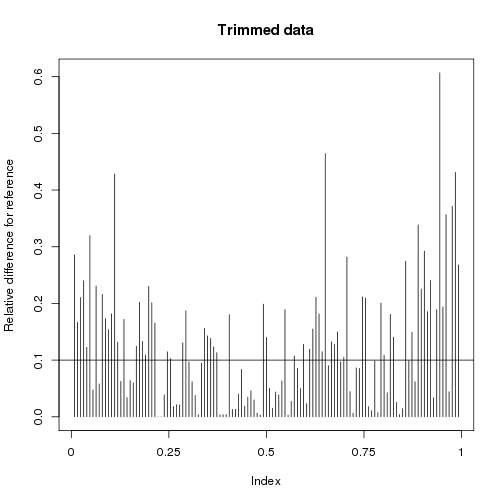

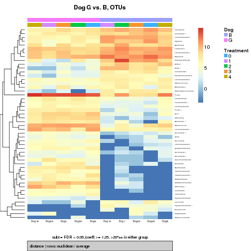

```
## [1] "making heatmap of results"
```

```
##         percent_positive_group0 percent_positive_group1
## OTU_40                      100                     100
## OTU_43                      100                     100
## OTU_11                      100                     100
## OTU_61                      100                      80
## OTU_87                      100                      20
## OTU_111                      80                       0
## OTU_19                      100                     100
## OTU_77                      100                      80
## OTU_73                      100                     100
## OTU_53                      100                     100
## OTU_18                      100                     100
## OTU_21                      100                     100
## OTU_29                      100                     100
## OTU_33                      100                     100
## OTU_49                      100                     100
## OTU_10                      100                     100
## OTU_46                      100                     100
## OTU_12                      100                     100
## OTU_51                      100                     100
## OTU_59                      100                     100
## OTU_96                       80                     100
## OTU_103                      60                     100
## OTU_150                     100                     100
## OTU_101                     100                     100
## OTU_24                      100                     100
## OTU_140                     100                     100
## OTU_97                      100                     100
## OTU_76                       80                     100
## OTU_54                       80                     100
## OTU_179                      80                     100
## OTU_100                       0                     100
## OTU_144                      40                      20
## OTU_121                     100                     100
## OTU_27                      100                     100
## OTU_8                       100                     100
## OTU_74                       60                     100
## OTU_82                       60                     100
## OTU_99                       40                      40
## OTU_26                      100                     100
```

[output cut: 251 more lines]

```
## OTU_74     [Mogibacteriaceae]
## OTU_82        Lachnospiraceae
## OTU_99        Veillonellaceae        Megasphaera
## OTU_26                  S24-7
## OTU_58    Succinivibrionaceae Anaerobiospirillum
## OTU_69         Bacteroidaceae        Bacteroides   uniformis
## OTU_52     Porphyromonadaceae    Parabacteroides
## OTU_68    Succinivibrionaceae Anaerobiospirillum
## OTU_72      Coriobacteriaceae      Adlercreutzia
## OTU_57    Succinivibrionaceae
## OTU_81
## OTU_36   [Paraprevotellaceae]               <NA>        <NA>
## OTU_55
## OTU_107  [Paraprevotellaceae]       [Prevotella]
## OTU_42   [Paraprevotellaceae]       [Prevotella]
```